# 9.KNN_Q slides

## KNN

### Da-Wei Chiang

## 大綱

- 一個簡單的例子
- `KNN`演算法
- `Scikit-Learn`簡介
- `KNN`實務
- `KNN`總結

## 一個簡單的例子

- 假定有個散步圖呈現如下
  - x軸表示的是年紀
  - y軸表示的是薪資
- 請大家猜猜紅點是屬於`man`還`Woman`？

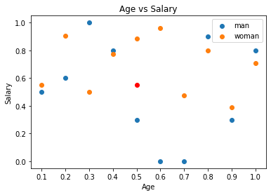

```python
import numpy as np
import random
import matplotlib.pyplot as plt
x_coor = [round(i, 1) for i in np.arange(0.1, 1.1, 0.1)]
man = [round(np.random.random(), 1) for i in range(1, 11)]
woman = [np.random.random() for i in range(1, 11)]
plt.scatter(x_coor, man, label='man')
plt.scatter(x_coor, woman, label='woman')
plt.scatter(0.5, 0.55, c='red')
plt.xticks(x_coor)
plt.xlabel("Age")
plt.ylabel("Salary")
plt.title("Age vs Salary")
plt.legend()
plt.show()
```

## `KNN`演算法

- `KNN`全名：`K Nearest Neighbors`
- `KNN`的問題核心：
  - 距離的定義
  - 選擇幾個鄰居

## 距離的定義

- 距離的定義
  - 每個物件(人或商品或...)都是`n`維空間中的點，通過計算點與點之間的距離來度量其相似性。
- 相似度的計算方式
  - 透過計算兩向量之間的距離`(Distance)`來度量樣本之間的相似度`(Similarity)`，距離越進則越相似 ; 距離越遠越不相同。
- 各種計算距離的方式
  - 歐式距離`(Euclidean Distance)`
  - 曼哈頓距離`(Manhattan Distance)`
  - 謝比雪夫距離`(Chebyshev Distance)`
  - 相似度`(Similarity)`
    - 夾角餘弦`(Cosine)`
    - 傑卡德相似係數`(Jaccard Similarity Coefficient)`

## 歐式距離`(Euclidean Distance)`

- 在歐式空間中，兩點之間的距離公式如下
  - 在二維平面上`a(x1,y1)與b(x2,y2)`間的歐氏距離為： $$d_{12} = \sqrt{(x_{1} - x_{2})^2 + (y_1 - y_2)^2}$$
  - 3D空間的兩點`A(x1,y1,z1)`與`B(x2,y2,z2)`間的歐氏距離為： $$d_{12} = \sqrt{(x_{1} - x_{2})^2 + (y_1 - y_2)^2 + (z_1 - z_2)^2}$$
  - n維空間下`A(x11,x12,...,x1n)`與`B(x21,x22,...,x2n)`間的歐氏距離為： $$d_{12} = \sqrt{\sum\limits_{k=1}^{n}(x_{1k}-x_{2k})^2}$$

## `Scikit-Learn`簡介

- `Scikit-Learn是Python`用於機器學習的重要函式庫
- `Scikit-Learn`的模組有意下幾種
  - 分類和回歸演算法
    - 廣義線性模型、線性和二次判斷分析、嶺回歸、支援向量機、隨機梯度下降、KNN、高斯過程、交換分解、單純貝氏、決策數、整合方法、多細粒度的演算法、特徵選擇、半監督、保序回歸、機率校準
  - 分群演算法
    - K-Means、仿射傳播、平均值飄移、譜分群、分層分群、DBSCAN、Birch
  - 維度約簡
    - PCA、潛在語意分析、字典學習、因數分析、ICA、非負矩陣分解
  - 模型選擇
    - 交換驗證、評價估計效能、網路搜索、搜索參數估計、模型預測品質的量化評價、模型的持久化、驗證曲線、繪製分數評價模型

## 安裝`sklearn`

```
pip install sklearn
conda install sklearn
```

## `KNN`實務

## 產生測試資料

```
from sklearn.datasets import make_blobs

data_Variable, label_Variable = make_blobs(n_samples, n_features, centers, cluster_std)

'''
參數說明：
    1. n_samples: 產生樣本個數
    2. n_features: 樣本特徵值(dim)
    3. centers: 預生成的樣本中心點(target)
    4. cluster_std: 每一類特徵值的標準差
'''
```

```python
from sklearn.datasets import make_blobs

x, y = make_blobs(n_samples = 10, n_features = 2, centers = 2)
print("x:%s" %x)
print("y:%s" %y)
```

```
x:[[-5.84494613  3.66898227]
 [-3.28020901  2.65470011]
 [ 4.66789286  4.70470307]
 [ 2.84624641  3.10461887]
 [ 4.59104251  2.45813182]
 [-4.55638542  3.02903543]
 [ 4.76300759  4.37845575]
 [-3.98147701  4.76947617]
 [ 4.05850088  3.80747665]
 [-5.68929942  2.33669695]]
y:[1 1 0 0 0 1 0 1 0 1]
```

## 練習

- 請產生100個樣本點，該樣本點有2種不同的特徵及4種不同的類別並且每個類別之間的資料標準差為1
- 請繪製散佈圖觀看其結果

## 劃分訓練及測試資料

```
from sklearn.model_selection import train_test_split
x_Train_Variable, x_Test_Variable, y_Train_Variable, y_Test_Variable = train_test_split(x_data, y_data, test_size)

'''
參數說明：
    1. x_data: 資料集
    2. y_data: 目標(target)
    3. test_size: 切割測試資料比率
'''
```

```python
## 範例
print("x:%s" %x)
print("y:%s" %y)
print("- - - - - - - - ")

from sklearn.model_selection import train_test_split

x_Train, x_Test, y_Train, y_Test = train_test_split(x, y, test_size=0.2)
print("x_Train:%s" %x_Train)
print("x_Test:%s" %x_Test)
print("y_Train:%s" %y_Train)
print("y_Test:%s" %y_Test)
```

```
x:[[-5.84494613  3.66898227]
 [-3.28020901  2.65470011]
 [ 4.66789286  4.70470307]
 [ 2.84624641  3.10461887]
 [ 4.59104251  2.45813182]
 [-4.55638542  3.02903543]
 [ 4.76300759  4.37845575]
 [-3.98147701  4.76947617]
 [ 4.05850088  3.80747665]
 [-5.68929942  2.33669695]]
y:[1 1 0 0 0 1 0 1 0 1]
- - - - - - - -
x_Train:[[ 4.59104251  2.45813182]
 [-4.55638542  3.02903543]
 [ 4.76300759  4.37845575]
 [ 4.66789286  4.70470307]
 [-3.28020901  2.65470011]
 [-5.68929942  2.33669695]
 [-5.84494613  3.66898227]
 [ 4.05850088  3.80747665]]
x_Test:[[-3.98147701  4.76947617]
 [ 2.84624641  3.10461887]]
y_Train:[0 1 0 0 1 1 1 0]
y_Test:[1 0]
```

## 練習

- 承上題
  - 對於100個樣本點劃分`Train、Test DataSet`
  - 分別畫出訓練及測試資料的散佈圖

## 使用`KNN Classification`模型

```
from sklearn.neighbors import KNeighborsClassifier    #import package

Model_Variable = KNeighborsClassifier(n_neighbors=k Value, algorithm, metric)  #Create KNN Model
Model_Variable.fit(x_Train_Data, y_Train_Data)  #Training Model
Prediction_Variable = Model_Variable.predict(x_Test_Data)   #Predict
Model_Variable.score(x_Test_Data, y_Test_Data)     #Score

'''
n_neighbor:幾個近鄰
algorithm:儲存結構演算法，預設為auto，可設ball_tree，kd_tree，brute
metric：預設為minkowski(明可夫斯基距離)，為歐式距離與曼哈頓距離兩種運算的延伸
'''
```

```python
# 範例
from sklearn.neighbors import KNeighborsClassifier

#print("x_Train:%s" %x_Train)
#print("x_Test:%s" %x_Test)
#print("y_Train:%s" %y_Train)
#print("y_Test:%s" %y_Test)
KNN = KNeighborsClassifier(3)
KNN.fit(x_Train, y_Train)
Prediction = KNN.predict(x_Test)
print(Prediction)
print(KNN.score(x_Test, y_Test))
```

```
[1 0]
1.0
```

## 練習 : Sklearn

- 使用`make_blobs（100個樣本點，該資料含有四種不同的特徵及兩種不同的類別，各類別之間的資料標準差為10）Training KNN Model`

## `KNN`的應用

- 上述的例子中我們使用`KNN`的概念來`Training Classification`的模型
- `KNN`除了可以拿來做分類模型之外, 也可以拿來訓練`Regression`的模型(數值型預測)
- `KNN Regression`的概念
  - 從選擇的`K`個鄰居中計算`target column`的平均值作為預測值

## 使用`KNN Regression`模型

```
from sklearn.neighbors import KNeighborsRegressor    #import package

Model_Variable = KNeighbosRegressor(n_neighbors=k Value, algorithm, metric)  #Create KNN Model
Model_Variable.fit(x_Train_Data, y_Train_Data)  #Training Model
Prediction_Variable = Model_Variable.predict(x_Test_Data)   #Predict
Model_Variable.score(x_Test_Data, y_Test_Data)     #Score

'''
n_neighbor:幾個近鄰
algorithm:儲存結構演算法，預設為auto，可設ball_tree，kd_tree，brute
metric：預設為minkowski(明可夫斯基距離)，為歐式距離與曼哈頓距離兩種運算的延伸
'''
```

```python
# 範例
from sklearn.neighbors import KNeighborsRegressor

X = [[0], [1], [2], [3]]
y = [10, 15, 20, 25]

knn = KNeighborsRegressor(2)
knn.fit(X, y)

x = 1.5
print('knn redression predict = ', knn.predict([[x]]))  #(15+20)/2

x = 4
print('knn redression predict = ', knn.predict([[x]]))  #(20+25)/2
```

```
knn redression predict =  [17.5]
knn redression predict =  [22.5]
```

## 實務練習 - 資料集下載

- 請使用[醫療保險金資料集](https://drive.google.com/file/d/1Bn7fk3fYmdMj3N2n-3BQuyrVjmnTZigp/view?usp=sharing)訓練`KNN`模型
- 預測醫療保險金.

## `KNN`總結

- 優點：
  - 易於理解、實作
- 缺點：
  - 計算量大（對於每個點都需要計算距離）
  - 對於不明平衡數據集相當敏感

## `KNN`問題

- `KNN`是屬於哪一種類型的演算法？分群、分類？
- `KNN`可以進行幾元分類？

## 作業

- 請各位在不使用`sklearn KNN model`的情況下撰寫`KNN`演算法